# Model Selection

GPA Example

GPA example from Graybill and Iyer (1994); worked in Burnham and Anderson (2002; p. 226)

SAT scores for Math and Verbal sections; High School GPAs for Math and English; GPA is the first-year college Grade Point Average (GPA).

```r
GPA_data <- read.csv("data/GPA.txt", sep="")
```

```r
head(GPA_data)
```

```
##   ID  GPA SATmath SATverbal HSmath HSverbal
## 1  1 1.97     321       247   2.30     2.63
## 2  2 2.74     718       436   3.80     3.57
## 3  3 2.19     358       578   2.98     2.57
## 4  4 2.60     403       447   3.58     2.21
## 5  5 2.98     640       563   3.38     3.48
## 6  6 1.65     237       342   1.48     2.14
```

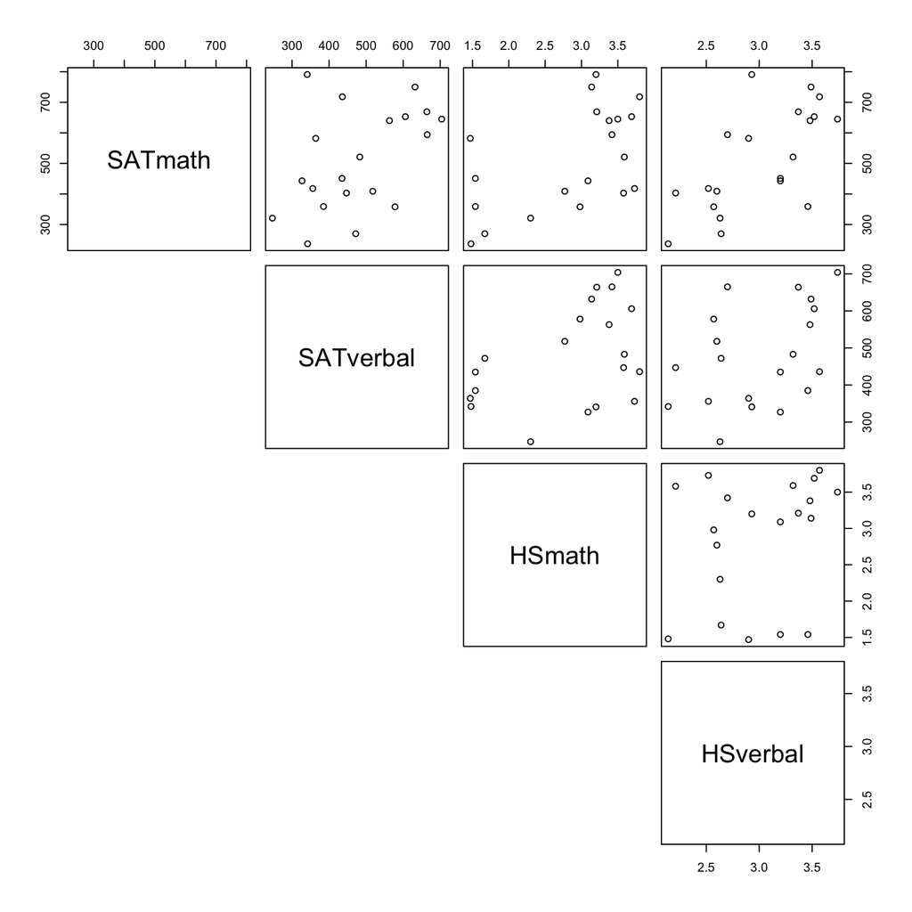

```r
#check for co-linearity
pairs(GPA_data[,3:6], lower.panel = NULL)
```

```r
correlation.matrix <- cor(GPA_data[,3:6])
round(correlation.matrix, 2)
```

```
##           SATmath SATverbal HSmath HSverbal
## SATmath      1.00      0.46   0.56     0.66
## SATverbal    0.46      1.00   0.43     0.42
## HSmath       0.56      0.43   1.00     0.27
## HSverbal     0.66      0.42   0.27     1.00
```

Some apparent colinearity among variables (HSverbal and SATmath). Anything above ~0.5 we should look at, but OK for now.

```r
# fit the full model with all parameters (sometimes called 'global')
GPA.all.parms<-lm(GPA ~ SATmath + SATverbal + HSmath + HSverbal, data = GPA_data)
```

Added variable plots are a quick diagnosis to see what variables in the global model are likely to be influential.

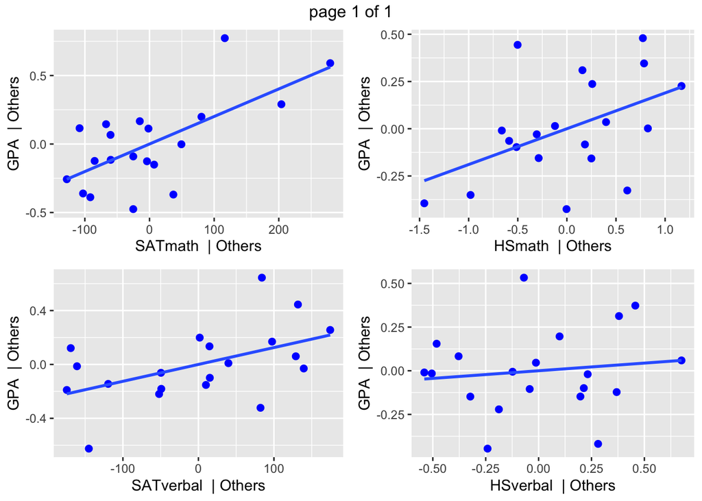

```r
olsrr::ols_plot_added_variable(GPA.all.parms)
```

https://olsrr.rsquaredacademy.com/articles/regression_diagnostics

Added variable plot provides information about the marginal (adjusted) importance of a predictor variable 𝑋, given the other predictor variables already in the model. It shows the marginal importance of the variable in reducing the residual (unexplained) variability.

The added variable plot was introduced by Mosteller and Tukey (1977). It enables us to visualize the regression coefficient of a new variable being considered to be included in a model. The plot can be constructed for each predictor variable.

A strong pos/neg relationship in the added variable plot indicates the increased importance of the contribution of X to the model **already containing the other predictors**.

In this case *HSverbal* doesn’t look like it contributes much explanatory power to the full model (very flat slope).

```r
# the dredge function fits all combinations
# of the variables in the GPA.all.parms model fit above
results<-MuMIn::dredge(GPA.all.parms) # note use of 'MuMIn' package
results
```

```
## Global model call: lm(formula = GPA ~ SATmath + SATverbal + HSmath + HSverbal, data = GPA_data)
## ---
## Model selection table
##     (Intrc)  HSmth   HSvrb    SATmt    SATvr df  logLik AICc delta weight
## 14  0.33420 0.1799         0.002185 0.001312  5   0.632 13.0  0.00  0.454
## 13  0.50710                0.002606 0.001574  4  -1.703 14.1  1.05  0.268
## 6   0.64380 0.2331         0.002510           4  -2.662 16.0  2.97  0.103
## 16  0.16150 0.1894 0.08756 0.002010 0.001252  6   0.795 16.9  3.85  0.066
## 15  0.48630        0.01115 0.002586 0.001568  5  -1.701 17.7  4.67  0.044
## 8   0.26900 0.2474 0.17560 0.002129           5  -2.159 18.6  5.58  0.028
## 5   0.96700                0.003178           3  -5.572 18.6  5.62  0.027
## 7   0.76700        0.09893 0.002987           4  -5.452 21.6  8.55  0.006
## 12 -0.42330 0.3405 0.45330          0.001423  5  -5.020 24.3 11.30  0.002
## 4  -0.34000 0.4171 0.57900                    4  -7.251 25.2 12.15  0.001
## 10  0.56720 0.3694                  0.002032  4  -8.284 27.2 14.21  0.000
## 11 -0.05721        0.51950          0.002273  4 -10.109 30.9 17.86  0.000
## 2   1.14700 0.5066                            3 -11.772 31.0 18.02  0.000
## 9   1.12800                         0.003063  3 -12.798 33.1 20.07  0.000
## 3   0.24870        0.77900                    3 -13.777 35.1 22.03  0.000
## 1   2.59300                                   2 -18.363 41.4 28.41  0.000
## Models ranked by AICc(x)
```

```r
# grab best supported models
subset(results, delta <5)
```

```
## Global model call: lm(formula = GPA ~ SATmath + SATverbal + HSmath + HSverbal, data = GPA_data)
## ---
## Model selection table
##    (Intrc)  HSmth   HSvrb    SATmt    SATvr df logLik AICc delta weight
## 14  0.3342 0.1799         0.002185 0.001312  5  0.632 13.0  0.00  0.485
## 13  0.5071                0.002606 0.001574  4 -1.703 14.1  1.05  0.287
## 6   0.6438 0.2331         0.002510           4 -2.662 16.0  2.97  0.110
## 16  0.1615 0.1894 0.08756 0.002010 0.001252  6  0.795 16.9  3.85  0.071
## 15  0.4863        0.01115 0.002586 0.001568  5 -1.701 17.7  4.67  0.047
## Models ranked by AICc(x)
```

Models 14 and 13 have delta AICc <2. Model 14 is about 1.69 times more likely than Model 13 (0.485/0.287=1.69).

```r
# calculate variable importance weights
MuMIn::sw(results)
```

```
##                      SATmath SATverbal HSmath HSverbal
## Sum of weights:      1.00    0.83      0.65   0.15
## N containing models:    8       8         8      8
```

Tells us that HSverbal is not really a useful predictor, and it is absent in all of the 3 top models.

Only fit models without HSverbal.

```r
results<-dredge(GPA.all.parms, subset= !(HSverbal))
results
```

```
## Global model call: lm(formula = GPA ~ SATmath + SATverbal + HSmath + HSverbal, data = GPA_data)
## ---
## Model selection table
##    (Intrc)  HSmth    SATmt    SATvr df  logLik AICc delta weight
## 14  0.3342 0.1799 0.002185 0.001312  5   0.632 13.0  0.00  0.532
## 13  0.5071        0.002606 0.001574  4  -1.703 14.1  1.05  0.315
## 6   0.6438 0.2331 0.002510           4  -2.662 16.0  2.97  0.121
## 5   0.9670        0.003178           3  -5.572 18.6  5.62  0.032
## 10  0.5672 0.3694          0.002032  4  -8.284 27.2 14.21  0.000
## 2   1.1470 0.5066                    3 -11.772 31.0 18.02  0.000
## 9   1.1280                 0.003063  3 -12.798 33.1 20.07  0.000
## 1   2.5930                           2 -18.363 41.4 28.41  0.000
## Models ranked by AICc(x)
```

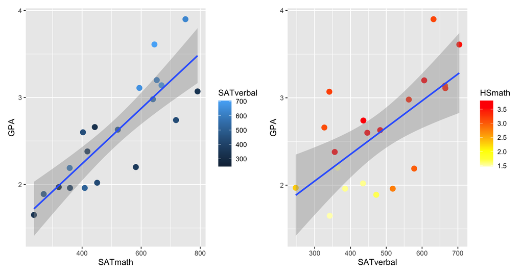

```r
#trying to represent combinations of our three most important variables on predicting GPA
p3 <- ggplot(GPA_data, aes(SATmath, GPA, colour = SATverbal)) +
  geom_point(size=3) +
  geom_smooth(method="lm")

p4 <- ggplot(GPA_data, aes(SATverbal, GPA, colour = HSmath)) +
  geom_point(size=3) +
  geom_smooth(method="lm") +
  scale_colour_gradientn(colours = heat.colors(10, rev=TRUE))

p3+p4 #uses 'patchwork' library to put plots next to each other
```

“Dredging” used here is just an example for comparing models. Dregding is known to prefer over-complex models. https://dynamicecology.wordpress.com/2015/05/21/why-aic-appeals-to-ecologists-lowest-instincts/